# Player Weapons UI

In this lesson, we handle the player controller targeting requests using the previously built UI.

We handle both projectile and laser weapons since we covered the bulk of the implementation when dealing with the AI weapons system.

By the end of this lesson you should get this result:

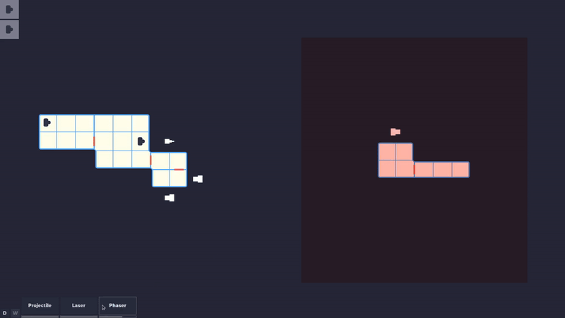

We offer player feedback using a targeting reticle for the projectile weapon. The numbers represent the position of the weapon in the player ship scene tree.

The UI button positioning at the bottom of the screen also reflects this order.

The laser uses the same system the AI does - a laser targeting path that the player can draw when entering the targeting mode for this type of weapon.

## Projectile weapon targeting

Lets add a targeting reticle to the *Room* scene for player feedback when targeting with the projectile weapon.

Open the *Room* scene and add these new

[figure not shown]

`Sprite` nodes to the tree:

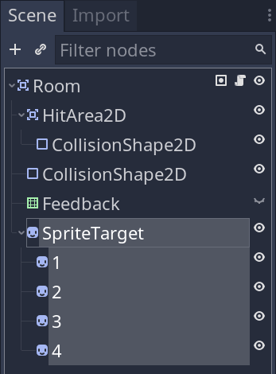

Assign the `Asset.svg` atlas to `Texture`. You can do this for all nodes simultaneously by selecting them like in the image above. Also, turn on *Region -> Enabled* to assign the appropriate visuals from the atlas:

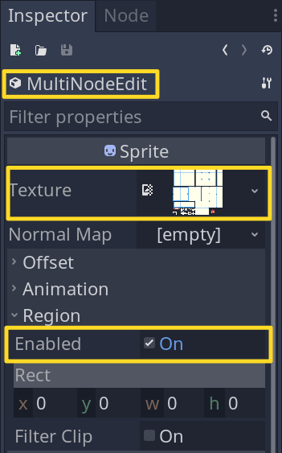

We’ll have to go in one by one and set the *Region -> Rect* property:

- *SpriteTarget*: `Rect(96, 384, 32 32)`
- *SpriteTarget -> 1*: `Rect(88, 384, 8, 8)`
- *SpriteTarget -> 2*: `Rect(88, 392, 8, 8)`
- *SpriteTarget -> 3*: `Rect(88, 400, 8, 8)`
- *SpriteTarget -> 4*: `Rect(88, 408, 8, 8)`

*SpriteTarget*’s children nodes are numbers we use to identify which projectile weapon tagerts which *Room*. Set these *Transform -> Position* properties:

- *SpriteTarget -> 1*: `Vector2(0, -16)`
- *SpriteTarget -> 2*: `Vector2(16, 0)`
- *SpriteTarget -> 3*: `Vector2(0, 16)`
- *SpriteTarget -> 4*: `Vector2(-16, 0)`

I used `#73275c` for *Visibility -> Modulate*, on *SpriteTarget*, which colors itself and all its children.

Your scene should now look like this:

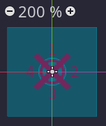

Select all of these sprites once more and turn off *Visibility -> Visible*.

We use the number sprites to indicate which weapon targets which room since the ship can have multiple weapons of the same type.

Furthermore, multiple weapons can target the same *Room*.

The numbers indicate the projectile’s weapon position in the UI.

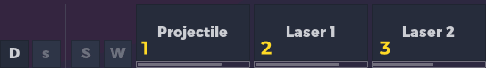

In this example, we have the projectile weapon placed first, which means it uses *SpriteTarget -> 1* when targeting.

## Preparatory updates

Before getting to the core of this lesson, we need to update a couple of scripts with minor changes.

You may notice above that there’s a maximum of `4` weapon slots for the player ship.

We’ll point out this design limitation with a warning like we did for the controllers and weapons.

Open the `ShipTemplate.gd` script and add the following function:

```
func _get_configuration_warning() -> String:
    var is_verified := (
        is_in_group("player")
        and weapons.get_child_count() <= 4
        or not is_in_group("player")
    )
    return "" if is_verified else "%s can't have more than 4 weapons!" % name
```

This limitation is placed only on the player ship. If the ship designer doesn’t hold to this limitation, the game can give a run-time error.

You might need to save the project and go to *Scene -> Reload Saved Scene* to let Godot handle `_get_configuration_warning()` correctly.

Now, we need to identify which weapons correspond with which buttons on the UI. Open the `Weapon.gd` script and add the following variable:

```
export var weapon_name := ""
# export var charge_time := 2.0
# ...
```

We’ll also update the warning messages implemented with `_get_configuration_warning()` to consider our future player controllers.

Open `WeaponProjectile.gd` and replace `_get_configuration_warning()` with:

```
func _get_configuration_warning() -> String:
    var parent := get_parent()
    var is_verified := parent != null and parent is ControllerAIProjectile or parent is ControllerPlayerProjectile
    return "" if is_verified else "WeaponProjectile needs to be a parent of Controller*Projectile"
```

Do the same in `WeaponLaser.gd`:

```
func _get_configuration_warning() -> String:
    var parent := get_parent()
    var is_verified := parent != null and parent is ControllerAILaser or parent is ControllerPlayerLaser
    return "" if is_verified else "WeaponLaser needs to be a parent of Controller*Laser"
```

You’ll get an error because *ControllerPlayerLaser* and *ControllerPlayerProjectile* aren’t implemented yet. We’ll get to them next.

## The player controllers

We now have all the necessary building blocks to start coding the player-UI interaction.

Start by creating a new script file at `res://TacticalSpaceCombat/Ship/Weapons/ControllerPlayer.gd` with the following top-level declarations:

```
class_name ControllerPlayer
extends Controller

var _ui_weapon_button: Button
var _ui_weapon_progress_bar: ProgressBar
```

Because UI handling overlaps in both classes, we use this intermediary script between `Controller.gd` on the one hand and `ControllerPlayerProjectile.gd` and `ControllerPlayerLaser.gd` on the other hand.

By coding the player-UI handling here, we avoid passing messages via signals between the UI and the game world.

It simplifies the code significantly.

Let’s continue with the `setup()` and `_ready()` functions:

```
func setup(ui_weapon: VBoxContainer) -> void:
    _ui_weapon_button = ui_weapon.get_node("Button")
    _ui_weapon_progress_bar = ui_weapon.get_node("ProgressBar")

    # Remember we defined `MIN_CHARGE` and `MAX_CHARGE` on `Weapon`. Since they
    # could be anything, we make sure to assign these values to the
    # `ProgressBar` to keep it consistent.
    _ui_weapon_progress_bar.min_value = Weapon.MIN_CHARGE
    _ui_weapon_progress_bar.max_value = Weapon.MAX_CHARGE

    # We use the "trick" that `gui_input` is a signal on `Control` nodes instead
    # of overwriting the `_gui_input()` function in a script attached to
    # UIWeapon
    _ui_weapon_button.connect("gui_input", self, "_on_UIWeaponButton_gui_input")
    _ui_weapon_button.connect("toggled", self, "_on_UIWeaponButton_toggled")
    _ui_weapon_button.text = weapon.weapon_name


func _ready() -> void:
    # We handle `ProgressBar` update to indicate charge time with this signal.
    weapon.tween.connect("tween_step", self, "_on_WeaponTween_tween_step")
```

Let’s add the missing functions now:

```
## The argument underscores tell Godot that we want to ignore their values.
## We're interested only in `value` here.
func _on_WeaponTween_tween_step(_o: Object, _k: NodePath, _e: float, value: float) -> void:
    _ui_weapon_progress_bar.value = value


## Cancels targeting mode on `RMB` click on the button.
func _on_UIWeaponButton_gui_input(event: InputEvent) -> void:
    if event.is_action_pressed("right_click"):
        _ui_weapon_button.pressed = false


## Updates the mouse cursor when the player enters or leaves targeting mode.

## Since `Input` is a singleton that's available to us from anywhere in code, we
## use the cursor shape as a global value for checking if the player entered
## targeting mode instead of keeping track of it through a custom global
## variable.
func _on_UIWeaponButton_toggled(is_pressed: bool) -> void:
    var cursor_shape := Input.CURSOR_CROSS if is_pressed else Input.CURSOR_ARROW
    Input.set_default_cursor_shape(cursor_shape)
```

The player needs a way to cancel targeting. We implement this in the `_input()` function which isn’t blocked by the

[figure not shown]

`Control` nodes:

```
func _input(event: InputEvent) -> void:
    if (
        event.is_action("right_click")
        and _ui_weapon_button.pressed
        # Note the use of `Input.CURSOR_CROSS` to check if the player is in
        # targeting mode.
        and Input.get_current_cursor_shape() == Input.CURSOR_CROSS
    ):
        _ui_weapon_button.pressed = false
```

We have now finished implementing the common code for player-UI interaction. We can now move to code the `ControllerPlayer*.gd` subclasses.

### The player projectile controller

We implemented the bulk of the functionality for the weapons and base controller scripts, all that’s left is coding the base implementation for the specialized controllers.

Let’s start with *ControllerPlayerProjectile*. Make a new script at `res://TacticalSpaceCombat/Ship/Weapons/ControllerPlayerProjectile.gd` with the following content:

```
class_name ControllerPlayerProjectile
extends ControllerPlayer

func _ready() -> void:
    # Remember  we initialize the projectile weapon with info on the enemy ship
    # physics layer.
    weapon.setup(Global.Layers.SHIPAI)


func _on_Ship_targeted(msg: Dictionary) -> void:
    ._on_Ship_targeted(msg)

    if msg.index == get_index():
        _ui_weapon_button.pressed = false
    # On top of the setting the targeting information on the weapon, we also try
    # to fire the weapon. This is so we can handle the case in which the weapon
    # is fully chared when the player targets a room.
    match msg:
        {"type": Type.PROJECTILE, ..}:
            weapon.fire()


func _on_UIWeaponButton_gui_input(event: InputEvent) -> void:
    ._on_UIWeaponButton_gui_input(event)
    if event.is_action_pressed("right_click"):
        # Cancel projectile weapon targeting on `right_click` by resetting
        # `weapon.target_position` even if targeting mode isn't enabled yet.
        weapon.target_position = Vector2.INF

        # We use the same `targeting` signal when disengaging to turn off the
        # numbered reticle.
        emit_signal("targeting", {"index": get_index()})

        # We trigger it one more time to reset the targeting state to an
        # invalid value. More on this when covering the `Room` script.
        emit_signal("targeting", {"index": -1})


func _on_UIWeaponButton_toggled(is_pressed: bool) -> void:
    ._on_UIWeaponButton_toggled(is_pressed)

    # We initialize the weapon `index` with an invalid position which signifies
    # that the player might cancel the process if not updated.
    var index := -1
    if is_pressed:
        # Entering the targeting mode updates the weapon index and resets the
        # weapon targeting state.
        index = get_index()
        weapon.target_position = Vector2.INF

    emit_signal("targeting", {"index": index})
```

### The player laser controller

We’ll now cover *ControllerPlayerLaser*. Create a new script at `res://TacticalSpaceCombat/Ship/Weapons/ControllerPlayerLaser.gd` with the following content:

```
class_name ControllerPlayerLaser
extends ControllerPlayer


func _on_Ship_targeted(msg: Dictionary) -> void:
    ._on_Ship_targeted(msg)

    # Unlike the projectile controller, I decided to reset the firing state
    # after every laser swipe since lasers are supposed to be used as precision
    # weapons. And later, they'll also be stopped by shields.
    _ui_weapon_button.pressed = false

    # Like before, we try firing the weapon to cover the case in which the
    # weapon is fully charged.
    match msg:
        {"type": Type.LASER, "success": true}:
            weapon.fire()


func _on_UIWeaponButton_gui_input(event: InputEvent) -> void:
    ._on_UIWeaponButton_gui_input(event)
    if event.is_action_pressed("right_click"):
        weapon.has_targeted = false


func _on_UIWeaponButton_toggled(is_pressed: bool) -> void:
    ._on_UIWeaponButton_toggled(is_pressed)
    # Note that, unlike `ControllerAILaser`, we also send `is_targeting` state
    # based on the button press state. We can use this later, to distinguish
    # between player and AI requests as well as knowing when to enter and exit
    # targeting mode in `LaserTracker`.
    var msg := {"is_targeting": is_pressed, "targeting_length": weapon.targeting_length}
    emit_signal("targeting", msg)
```

This concludes coding the player controller scripts.

Remember, we add controllers to the ships scene tree from the node add menu:

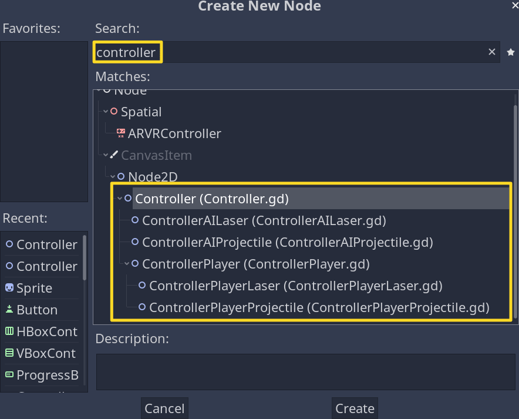

## Handling player interaction

Lets move onto handling the incoming player targeting requests from the controllers we implemented above.

### Projectile controller requessts

We have to update the `Room.gd` script to handle the player targeting interaction. Open the script and start with the signal declaration at the top:

```
## Emitted after we handle the target reticle (`SpriteTarget`). It sends the
## `Room` position, among other information.
signal targeted(msg)
```

This should look familiar. We used the same strategy when coding the `Rooms.gd` script, but we handle the interaction per *Room* for the player this time.

Let’s add a variable to hold the target index:

```
# ...
# export var size := Vector2.ONE setget set_size

## We initialize it with an invalid value that will help us in checking for
## targeting conditions.
var _target_index := -1
```

And add a reference variable to *SpriteTarget*:

```
# ...
# onready var feedback: NinePatchRect = $Feedback
onready var sprite_target: Sprite = $SpriteTarget
```

Now to implement the function that handles the incoming targeting requests:

```
func _on_Controller_targeting(msg: Dictionary) -> void:
    # Update `_target_index`. This is useful when emitting `targeted` when
    # clicking on a `Room`.
    _target_index = msg.index

    # We might get an invalid input if the player cancels the targeting process.
    if _target_index != -1:
        # Every time the player enters targeting mode we first try to reset the
        # targeting reticle.
        sprite_target.visible = false

        # And the specific child reticle number given the weapon index.
        sprite_target.get_child(_target_index).visible = false

        for node in sprite_target.get_children():
            if node.visible:
                # If there are other visible children, other than `_target_index`,
                # then reenable the targeting reticle visibility and break out of
                # the loop since one is enough.
                sprite_target.visible = true
                break
```

For each *Room*, we need to handle click events. We can connect to an `input_event` signal to call our `_on_input_event()` function.

First lets define the function:

```
func _on_input_event(_v: Viewport, event: InputEvent, _s: int) -> void:
    if (
        event.is_action_pressed("left_click")

        # Note these checks. Like I mentioned before, we use
        # `Input.CURSOR_CROSS` to check for player targeting mode.
        and Input.get_current_cursor_shape() == Input.CURSOR_CROSS

        # And we further assume that if `_target_index != -1`, it has to be
        # valid and continue handling the `left_click`.
        and _target_index != -1
    ):
        # Turn on the appropriate targeting reticle.
        sprite_target.visible = true
        sprite_target.get_child(_target_index).visible = true

        # And send back the position of the Room along with the other weapon
        # information.
        emit_signal(
            "targeted",
            {
                "type": Controller.Type.PROJECTILE,
                "index": _target_index,
                "target_position": position
            }
        )
        _target_index = -1
```

Now we just need to connect the signal to the function:

```
func _ready() -> void:
    # ...
    # connect("area_entered", self, "_on_area_entered")
    connect("input_event", self, "_on_input_event")
```

This concludes handling the projectile player targeting requests and now we can move on to handling the laser controller.

### Laser controller requests

We have to expand the *LaserTracker* to handle player requests.

Open the `LaserTracker.gd` script. We start by defining a couple of new variables:

```
# ...
# const LINE_DEFAULT := PoolVector2Array([Vector2.INF, Vector2.INF])

## We keep track of the player targeting mode with this variable.
var _is_targeting := false

## We also need to track the laser weapon targeting length depending on which
## weapon the player uses.
var _targeting_length := 0
```

Lets update the `_on_Controller_targeting()` function. Replace it with this new implementation:

```
func _on_Controller_targeting(msg: Dictionary) -> void:
    match msg:
        # We separate player and AI through the `is_targeting` key.
        {"targeting_length": var targeting_length, "is_targeting": var is_targeting}:
            _is_targeting = is_targeting
            _targeting_length = targeting_length
            if _is_targeting:
                # Handle targeting cancellation by resetting `target_line`.
                target_line.points = LINE_DEFAULT
        {"targeting_length": var targeting_length}:
            # We moved the previous AI implementation under this branch which
            # lacks the `is_targeting` key.
            target_line.points = _rooms.get_laser_points(targeting_length)
            emit_signal("targeted", {"type": Controller.Type.LASER, "success": true})
```

We now handle the player mouse LMB & drag for defining the targeting path. We do this in the `_unhandled_input()` function:

```
func _unhandled_input(event: InputEvent) -> void:
    # We filter out any non-mouse event as long as the player is in targeting
    # mode.
    if not (event is InputEventMouse and _is_targeting):
        return

    if event.is_action_pressed("left_click"):
        # On `left_click` we update the first point of `target_line`. This means
        # that the second point is still `Vector2.INF`.
        target_line.points[0] = get_local_mouse_position()

    elif target_line.points[0] != Vector2.INF and event is InputEventMouseMotion:
        # This handles the events after `left_click`, meaning as we drag the
        # mouse with the button pressed.

        # Update an`offset` relative to the first `left_click` position stored
        # in `target_line.points[0]`. We make sure to clamp its length to
        # `_targeting_length`.
        var offset: Vector2 = get_local_mouse_position() - target_line.points[0]
        offset = offset.clamped(_targeting_length)

        # Now we can commit the second point of the targeting path.
        target_line.points[1] = target_line.points[0] + offset

    elif event.is_action_released("left_click"):
        # If we finished dragging the mouse and release the `left_click` then we
        # commit to the calculated laser path by emitting the `targeted` signal
        # and switching out of the targeting mode.
        _is_targeting = false

        # If the player releases the `LMB` too fast then `success` will be `false`.
        var msg := {"type": Controller.Type.LASER, "success": target_line.points[1] != Vector2.INF}
        emit_signal("targeted", msg)
```

So this is the reason why we introduced the extra `success` key to the dictionary sent with the `targeted` signal. We need to cover an edge case when the player might accidentally or willingly press `LMB` and release before dragging the target path.

To finish up, we update the `_on_Weapon_fire_stopped()` function to reset the targeting path when the laser fire stops:

```
func _on_Weapon_fire_stopped() -> void:
    # tween.remove_all()
    target_line.points = LINE_DEFAULT
```

Unlike the AI, which targets continuously after each shot, the player can choose not to do so.

And that is player laser controller targeting requests wrapped up.

## Units selection during targeting

We need to handle one particular case when the player enters targeting mode.

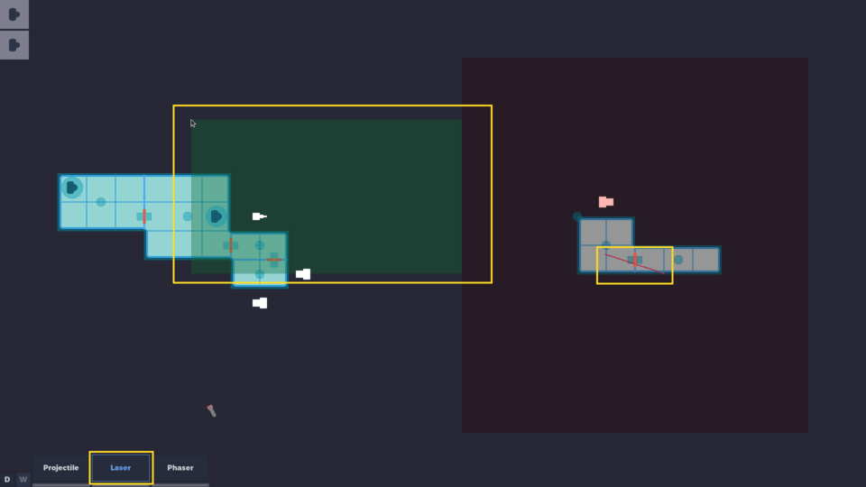

Notice that the player can still drag-select units with a selection box while targeting. This is not desired behaviour.

To fix it, open the `Units.gd` script and update the `_input()` function to filter out for targeting mode using the `Input` singleton:

```
func _input(event: InputEvent) -> void:
    if not (event is InputEventMouse and Input.get_current_cursor_shape() == Input.CURSOR_ARROW):
        return

    # ...
```

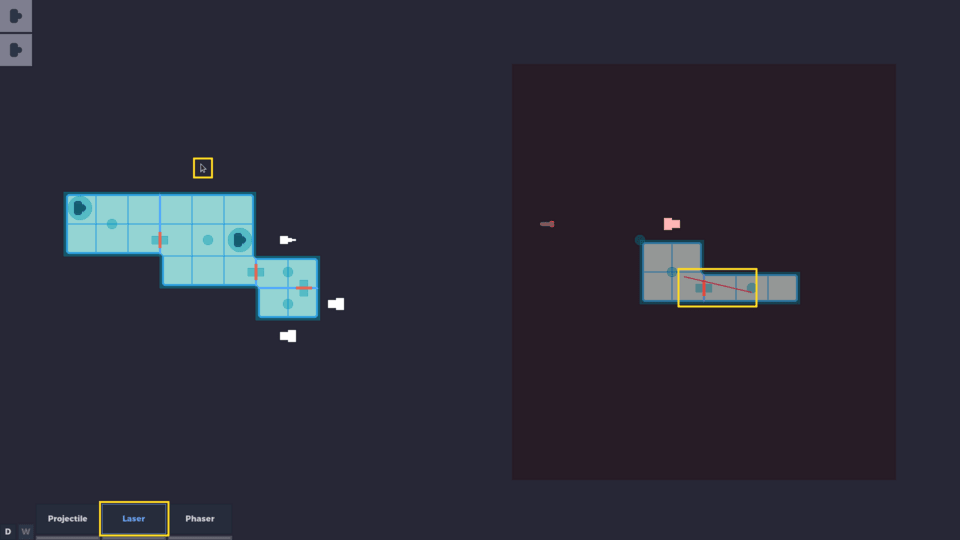

We’re ready to move to the final step - updating the `TacticalSpaceCombat.gd` script to add all the necessary connections for the player weapons.

## Adding the UI-controller-weapons connections

Open the `TacticalSpaceCombat.gd` script.

Let’s start by preloading a few scenes we’ll require for generating the UI:

```
# ...
# const UIUnit = preload("TacticalSpaceCombat/UI/UIUnit.tscn")
const UIWeapons = preload("TacticalSpaceCombat/UI/UIWeapons.tscn")
const UIWeapon = preload("TacticalSpaceCombat/UI/UIWeapon.tscn")
```

Add a reference to the new *UI -> Systems* node:

```
# ...
# onready var ui_doors: Button = $UI/Systems/Doors
onready var ui_systems: HBoxContainer = $UI/Systems
```

Like in the AI case, we’ll add a `_ready_weapons_player()` function to set up all the necessary signal connections.

```
func _ready_weapons_player() -> void:
    for controller in ship_player.weapons.get_children():
        if not ui_systems.has_node("Weapons"):
            ui_systems.add_child(UIWeapons.instance())
        var ui_weapon: VBoxContainer = UIWeapon.instance()
        ui_systems.get_node("Weapons").add_child(ui_weapon)

        if controller is ControllerPlayerProjectile:
            controller.weapon.connect(
                "projectile_exited", ship_ai.projectiles, "_on_Weapon_projectile_exited"
            )
            for room in ship_ai.rooms.get_children():
                controller.connect("targeting", room, "_on_Controller_targeting")
                room.connect("targeted", controller, "_on_Ship_targeted")

        elif controller is ControllerPlayerLaser:
            var laser_tracker: Node = ship_ai.add_laser_tracker(controller.weapon.color)
            controller.connect(
                "targeting", laser_tracker, "_on_Controller_targeting", [], CONNECT_DEFERRED
            )
            controller.weapon.connect("fire_started", laser_tracker, "_on_Weapon_fire_started")
            controller.weapon.connect("fire_stopped", laser_tracker, "_on_Weapon_fire_stopped")
            laser_tracker.connect("targeted", controller, "_on_Ship_targeted")
        controller.setup(ui_weapon)
```

This is similar to what we did for the AI controllers. Except here, we also create the weapons UI dynamically, based on the weapons attached to the player ship.

In the end, we initialize the player controllers with `controller.setup(ui_weapon)` to handle button interactions.

The final step is to call the function in `_ready()`:

```
func _ready() -> void:
    # ...
    # _ready_weapons_ai()
    _ready_weapons_player()
```

This concludes setting up the controller connections to the other systems in our demo.

## Checking the progress

To check our work, you can try and recreate a similar *ShipPlayer* scene like I did in the following steps.

I made these changes to the my *ShipPlayer* scene tree:

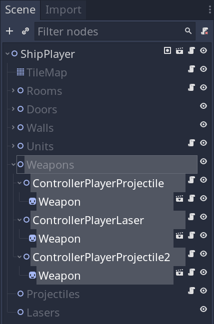

And made sure to assign the proper *Weapon* nodes.

I named *ControllerPlayerProjectile -> Weapon Projectile* in the *Inspector* by chainging the *Weapon Name* property. This will show up as the name of the

[figure not shown]

`Button` at the bottom of the screen. I left *Charge Time* unchanged.

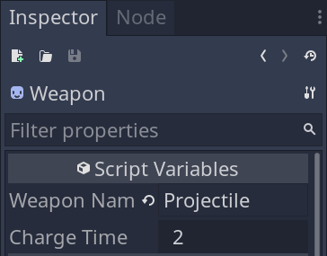

For *ControllerPlayerLaser -> Weapon* I changed *Weapon Name* to *Laser* and left the rest unchanged.

Finally, for *ControllerPlayerProjectile2 -> Weapon* I changed *Weapon Name* to *Phaser* and *Charge Time* to `6` for a bit of variation.

I moved the weapons at the end of the ship, by changing the location of *ControllerPlayer** nodes.

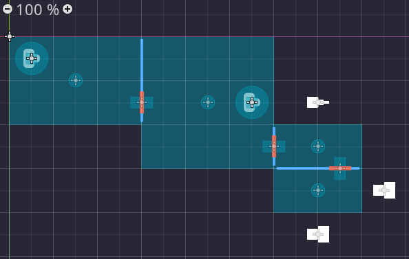

Now we’re ready to check the in-game progress by running the demo. Here’s a screenshot of the in-game look:

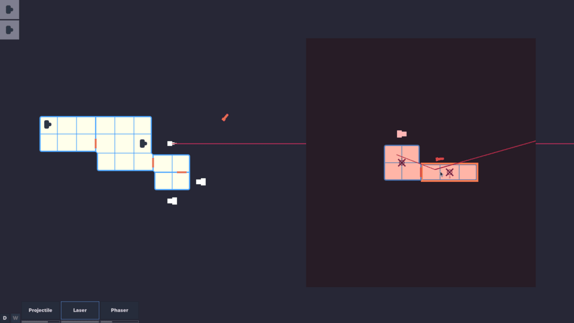

Though I tinted the AI ship viewport with a bit of pink so it stands out.

## Conclusion

We now have a working targeting system for both the player and the AI.

In this lesson, we implemented the player-controller-weapons system.

We saw how to handle complex player-UI interactions by transferring the responsibility to the game world instead of emitting signals from scripts attached to the UI system.

We updated our projectile-based system with an advanced targeting reticle that informs the player which weapons target rooms.

We covered the differences between player and AI targeting and how we can use built-in singletons to check for global state changes.

In our case, we used the `Input` singleton as a proxy for checking if the player is in targeting mode to handle signals appropriately.

Congratulations on getting this far!

This is a reasonably complex demo, and if you made it here, pat yourself on the back because it’s a challenging journey!

In the next chapter, we are adding hitpoints and a loss state before covering shields, room types and finishing up with a few effects to improve the demo’s look.

## Code reference

`res://TacticalSpaceCombat/Ship/ShipTemplate.gd`:

```
tool
extends Node2D

const LaserTracker := preload("Weapons/LaserTracker.tscn")

var _slots := {}

onready var tilemap: TileMap = $TileMap
onready var rooms: Node2D = $Rooms
onready var doors: Node2D = $Doors
onready var units: Node2D = $Units
onready var weapons: Node2D = $Weapons
onready var projectiles: Node2D = $Projectiles
onready var lasers: Node2D = $Lasers


func _ready() -> void:
    call("_ready_editor_hint" if Engine.editor_hint else "_ready_not_editor_hint")


func _ready_editor_hint() -> void:
    for room in rooms.get_children():
        room.setup(tilemap)


func _ready_not_editor_hint() -> void:
    for unit in units.get_children():
        for door in doors.get_children():
            door.connect("opened", unit, "set_is_walking", [true])

        var position_map := tilemap.world_to_map(unit.path_follow.position)
        _slots[position_map] = unit

    for room in rooms.get_children():
        room.setup(tilemap)
        for point in room:
            tilemap.set_cellv(point, 0)
    tilemap.setup(rooms, doors)
    projectiles.setup(rooms.mean_position)


func _get_configuration_warning() -> String:
    var is_verified := (
        is_in_group("player")
        and weapons.get_child_count() <= 4
        or not is_in_group("player")
    )
    return "" if is_verified else "%s can't have more than 4 weapons!" % name


func _unhandled_input(event: InputEvent) -> void:
    if not event.is_action_pressed("right_click"):
        return

    for unit in get_tree().get_nodes_in_group("selected-unit"):
        var point1: Vector2 = tilemap.world_to_map(unit.path_follow.position)
        for room in get_tree().get_nodes_in_group("selected-room"):
            if not room.owner.is_in_group("player"):
                break

            var point2: Vector2 = room.get_slot(_slots, unit)
            if is_inf(point2.x):
                break

            var path: Curve2D = tilemap.find_path(point1, point2)
            Utils.erase_value(_slots, unit)
            _slots[point2] = unit
            unit.walk(path)


func _on_UIDoorsButton_pressed() -> void:
    var has_opened_doors := false
    for door in doors.get_children():
        if door.is_open:
            has_opened_doors = true
            break

    for door in doors.get_children():
        door.is_open = not has_opened_doors


func add_laser_tracker(color: Color) -> Node:
    var laser_tracker := LaserTracker.instance()
    lasers.add_child(laser_tracker)
    laser_tracker.setup(color, rooms)
    return laser_tracker
```

`res://TacticalSpaceCombat/Ship/Weapons/Weapon.gd`:

```
class_name Weapon
extends Sprite

const MIN_CHARGE := 0
const MAX_CHARGE := 100

export var weapon_name := ""
export var charge_time := 2.0

var is_charging := false setget set_is_charging

var _charge := MIN_CHARGE

onready var tween: Tween = $Tween


func _ready() -> void:
    tween.connect("tween_all_completed", self, "set_is_charging", [false])
    self.is_charging = true


func fire() -> void:
    pass


func set_is_charging(value: bool) -> void:
    is_charging = value
    if is_charging:
        tween.interpolate_property(self, "_charge", MIN_CHARGE, MAX_CHARGE, charge_time)
        tween.start()
    fire()
```

`res://TacticalSpaceCombat/Ship/Weapons/WeaponProjectile.gd`:

```
tool
extends Weapon

signal fired
signal projectile_exited(params)

const Projectile := preload("Projectile.tscn")

var target_position := Vector2.INF

var _physics_layer := -1


func setup(physics_layer: int) -> void:
    _physics_layer = physics_layer


func _get_configuration_warning() -> String:
    var parent := get_parent()
    var is_verified := parent != null and parent is ControllerAIProjectile or parent is ControllerPlayerProjectile
    return "" if is_verified else "WeaponProjectile needs to be a parent of Controller*Projectile"


func fire() -> void:
    if not can_fire():
        return

    self.is_charging = true
    var projectile: RigidBody2D = Projectile.instance()
    projectile.linear_velocity = projectile.linear_velocity.rotated(global_rotation)
    var params := {"physics_layer": _physics_layer, "target_position": target_position}
    projectile.connect("tree_exited", self, "emit_signal", ["projectile_exited", params])
    add_child(projectile)
    emit_signal("fired")


func can_fire() -> bool:
    return not is_charging and target_position != Vector2.INF
```

`res://TacticalSpaceCombat/Ship/Weapons/WeaponLaser.gd`:

```
tool
extends Weapon

signal fire_started(params)
signal fire_stopped

export (int, 0, 250) var targeting_length := 140
export var color := Color("b0305c")

var has_targeted := false

onready var timer: Timer = $Timer
onready var line: Line2D = $Line2D


func _ready() -> void:
    if Engine.editor_hint:
        return

    timer.connect("timeout", self, "emit_signal", ["fire_stopped"])
    timer.connect("timeout", self, "set_is_charging", [true])
    timer.connect("timeout", line, "set_visible", [false])
    line.default_color = color


func _get_configuration_warning() -> String:
    var parent := get_parent()
    var is_verified := parent != null and parent is ControllerAILaser or parent is ControllerPlayerLaser
    return "" if is_verified else "WeaponLaser needs to be a parent of Controller*Laser"


func fire() -> void:
    if not can_fire():
        return

    timer.start()
    has_targeted = false
    line.visible = true
    var params := {"duration": timer.wait_time}
    emit_signal("fire_started", params)


func can_fire() -> bool:
    return not is_charging and has_targeted
```

`res://TacticalSpaceCombat/Ship/Weapons/ControllerPlayer.gd`:

```
class_name ControllerPlayer
extends Controller

var _ui_weapon_button: Button
var _ui_weapon_progress_bar: ProgressBar


func setup(ui_weapon: VBoxContainer) -> void:
    _ui_weapon_button = ui_weapon.get_node("Button")
    _ui_weapon_progress_bar = ui_weapon.get_node("ProgressBar")
    _ui_weapon_progress_bar.min_value = Weapon.MIN_CHARGE
    _ui_weapon_progress_bar.max_value = Weapon.MAX_CHARGE

    _ui_weapon_button.connect("gui_input", self, "_on_UIWeaponButton_gui_input")
    _ui_weapon_button.connect("toggled", self, "_on_UIWeaponButton_toggled")
    _ui_weapon_button.text = weapon.weapon_name


func _ready() -> void:
    weapon.tween.connect("tween_step", self, "_on_WeaponTween_tween_step")


func _input(event: InputEvent) -> void:
    if (
        event.is_action("right_click")
        and _ui_weapon_button.pressed
        and Input.get_current_cursor_shape() == Input.CURSOR_CROSS
    ):
        _ui_weapon_button.pressed = false


func _on_WeaponTween_tween_step(_o: Object, _k: NodePath, _e: float, value: float) -> void:
    _ui_weapon_progress_bar.value = value


func _on_UIWeaponButton_gui_input(event: InputEvent) -> void:
    if event.is_action_pressed("right_click"):
        _ui_weapon_button.pressed = false


func _on_UIWeaponButton_toggled(is_pressed: bool) -> void:
    var cursor_shape := Input.CURSOR_CROSS if is_pressed else Input.CURSOR_ARROW
    Input.set_default_cursor_shape(cursor_shape)
```

`res://TacticalSpaceCombat/Ship/Weapons/ControllerPlayerProjectile.gd`:

```
class_name ControllerPlayerProjectile
extends ControllerPlayer


func _ready() -> void:
    weapon.setup(Global.Layers.SHIPAI)


func _on_Ship_targeted(msg: Dictionary) -> void:
    ._on_Ship_targeted(msg)
    if msg.index == get_index():
        _ui_weapon_button.pressed = false

    match msg:
        {"type": Type.PROJECTILE, ..}:
            weapon.fire()


func _on_UIWeaponButton_gui_input(event: InputEvent) -> void:
    ._on_UIWeaponButton_gui_input(event)
    if event.is_action_pressed("right_click"):
        weapon.target_position = Vector2.INF
        emit_signal("targeting", {"index": get_index()})
        emit_signal("targeting", {"index": -1})


func _on_UIWeaponButton_toggled(is_pressed: bool) -> void:
    ._on_UIWeaponButton_toggled(is_pressed)
    var index := -1
    if is_pressed:
        index = get_index()
        weapon.target_position = Vector2.INF
    emit_signal("targeting", {"index": index})
```

`res://TacticalSpaceCombat/Ship/Weapons/ControllerPlayerLaser.gd`:

```
class_name ControllerPlayerLaser
extends ControllerPlayer


func _on_Ship_targeted(msg: Dictionary) -> void:
    ._on_Ship_targeted(msg)
    _ui_weapon_button.pressed = false

    match msg:
        {"type": Type.LASER, "success": true}:
            weapon.fire()


func _on_UIWeaponButton_gui_input(event: InputEvent) -> void:
    ._on_UIWeaponButton_gui_input(event)
    if event.is_action_pressed("right_click"):
        weapon.has_targeted = false


func _on_UIWeaponButton_toggled(is_pressed: bool) -> void:
    ._on_UIWeaponButton_toggled(is_pressed)
    var msg := {"is_targeting": is_pressed, "targeting_length": weapon.targeting_length}
    emit_signal("targeting", msg)
```

`res://TacticalSpaceCombat/Ship/Rooms/Room.gd`:

```
tool
class_name Room
extends Area2D

signal targeted(msg)

export var size := Vector2.ONE setget set_size

var _target_index := -1

var _rng := RandomNumberGenerator.new()

var _entrances := {}

var _area := 0
var _top_left := Vector2.ZERO
var _bottom_right := Vector2.ZERO

var _iter_index := 0

var _tilemap: TileMap = null

onready var collision_shape: CollisionShape2D = $CollisionShape2D
onready var feedback: NinePatchRect = $Feedback
onready var sprite_target: Sprite = $SpriteTarget


func setup(tilemap: TileMap) -> void:
    _tilemap = tilemap
    _setup_extents()

    _area = size.x * size.y
    _top_left = _tilemap.world_to_map(position - collision_shape.shape.extents)
    _bottom_right = _top_left + size

    feedback.rect_position -= collision_shape.shape.extents
    feedback.rect_size = 2 * collision_shape.shape.extents


func _setup_extents() -> void:
    if _tilemap != null:
        collision_shape.shape.extents = 0.5 * _tilemap.map_to_world(size)


func _ready() -> void:
    connect("mouse_entered", self, "_on_mouse_entered_exited", [true])
    connect("mouse_exited", self, "_on_mouse_entered_exited", [false])
    connect("area_entered", self, "_on_area_entered")
    connect("input_event", self, "_on_input_event")
    _rng.randomize()


func _on_input_event(_v: Viewport, event: InputEvent, _s: int) -> void:
    if (
        event.is_action_pressed("left_click")
        and Input.get_current_cursor_shape() == Input.CURSOR_CROSS
        and _target_index != -1
    ):
        sprite_target.visible = true
        sprite_target.get_child(_target_index).visible = true
        emit_signal(
            "targeted",
            {
                "type": Controller.Type.PROJECTILE,
                "index": _target_index,
                "target_position": position
            }
        )
        _target_index = -1


func _on_mouse_entered_exited(has_entered: bool) -> void:
    feedback.visible = has_entered
    var group := "selected-room"
    if has_entered:
        add_to_group(group)
    elif is_in_group(group):
        remove_from_group(group)


func _on_area_entered(area: Area2D) -> void:
    if area.is_in_group("door"):
        var entrance := position - area.position
        entrance = entrance.project(Vector2.DOWN.rotated(area.rotation)).normalized()
        entrance *= 0.5 * _tilemap.cell_size.x
        entrance += area.position
        entrance = _tilemap.world_to_map(entrance)
        _entrances[entrance] = null


func _on_Controller_targeting(msg: Dictionary) -> void:
    _target_index = msg.index
    if _target_index != -1:
        sprite_target.visible = false
        sprite_target.get_child(_target_index).visible = false
        for node in sprite_target.get_children():
            if node.visible:
                sprite_target.visible = true
                break


func randv() -> Vector2:
    var top_left_world := _tilemap.map_to_world(_top_left)
    var bottom_right_world := _tilemap.map_to_world(_bottom_right)
    return Utils.randvf_range(_rng, top_left_world, bottom_right_world)


func has_point(point: Vector2) -> bool:
    return Rect2(_top_left, size).has_point(point)


func set_size(value: Vector2) -> void:
    for axis in [Vector2.AXIS_X, Vector2.AXIS_Y]:
        size[axis] = max(1, value[axis])
    _setup_extents()


func get_slot(slots: Dictionary, unit: Unit) -> Vector2:
    var out := Vector2.INF
    var entrance := _get_entrance(_tilemap.world_to_map(unit.path_follow.position))

    var valid_positions := []
    for offset in self:
        valid_positions.push_back([offset, offset.distance_to(entrance)])
    valid_positions.sort_custom(self, "sort_by_second_index")

    for data in valid_positions:
        var offset: Vector2 = data[0]
        if not (offset in slots and slots[offset] != unit):
            out = offset
            break
    return out


static func sort_by_second_index(a: Array, b: Array) -> bool:
    return a[1] < b[1]


func _get_entrance(from: Vector2) -> Vector2:
    var out := Vector2.INF
    var distance := INF
    for entrance in _entrances:
        var curve: Curve2D = _tilemap.find_path(from, entrance)
        var length := curve.get_baked_length()
        if distance > length:
            distance = length
            out = entrance
    return out


func _iter_init(_arg) -> bool:
    _iter_index = 0
    return _iter_is_running()


func _iter_next(_arg) -> bool:
    _iter_index += 1
    return _iter_is_running()


func _iter_get(_arg) -> Vector2:
    var offset := Utils.index_to_xy(size.x, _iter_index)
    return _top_left + offset


func _iter_is_running() -> bool:
    return _iter_index < _area
```

`res://TacticalSpaceCombat/Ship/Weapons/LaserTracker.gd`:

```
extends Node2D

signal targeted(msg)

const LINE_DEFAULT := PoolVector2Array([Vector2.INF, Vector2.INF])

var _is_targeting := false
var _targeting_length := 0
var _rng := RandomNumberGenerator.new()
var _rooms: Node2D = null

onready var tween: Tween = $Tween
onready var area: Area2D = $Area2D
onready var line: Line2D = $Line2D
onready var target_line: Line2D = $TargetLine2D


func setup(color: Color, rooms: Node2D) -> void:
    _rooms = rooms
    line.default_color = color
    target_line.default_color = color


func _ready() -> void:
    _rng.randomize()
    target_line.points = LINE_DEFAULT
    line.points = LINE_DEFAULT


func _unhandled_input(event: InputEvent) -> void:
    if not (event is InputEventMouse and _is_targeting):
        return

    if event.is_action_pressed("left_click"):
        target_line.points[0] = get_local_mouse_position()
    elif target_line.points[0] != Vector2.INF and event is InputEventMouseMotion:
        var offset: Vector2 = get_local_mouse_position() - target_line.points[0]
        offset = offset.clamped(_targeting_length)
        target_line.points[1] = target_line.points[0] + offset
    elif event.is_action_released("left_click"):
        _is_targeting = false
        var msg := {"type": Controller.Type.LASER, "success": target_line.points[1] != Vector2.INF}
        emit_signal("targeted", msg)


func _on_Controller_targeting(msg: Dictionary) -> void:
    match msg:
        {"targeting_length": var targeting_length, "is_targeting": var is_targeting}:
            _is_targeting = is_targeting
            _targeting_length = targeting_length
            if _is_targeting:
                target_line.points = LINE_DEFAULT
        {"targeting_length": var targeting_length}:
            target_line.points = _rooms.get_laser_points(targeting_length)
            emit_signal("targeted", {"type": Controller.Type.LASER, "success": true})


func _on_Weapon_fire_started(params: Dictionary) -> void:
    if Vector2.INF in target_line.points:
        return

    line.points[0] = _rooms.mean_position + Utils.randvf_circle(_rng, Projectile.MAX_DISTANCE)
    tween.interpolate_method(
        self, "_swipe_laser", target_line.points[0], target_line.points[1], params.duration
    )
    tween.start()


func _on_Weapon_fire_stopped() -> void:
    tween.remove_all()
    target_line.points = LINE_DEFAULT
    line.points = LINE_DEFAULT
    area.position = Vector2.ZERO


func _swipe_laser(offset: Vector2) -> void:
    line.points[1] = offset
    area.position = line.points[1]
```

`res://TacticalSpaceCombat/Ship/Units.gd`:

```
extends Node2D

const DEFAULT_POLYGON := PoolVector2Array([Vector2.ZERO, Vector2.ZERO, Vector2.ZERO, Vector2.ZERO])

var _is_selecting := false
var _polygon := DEFAULT_POLYGON


func _input(event: InputEvent) -> void:
    if not (event is InputEventMouse and Input.get_current_cursor_shape() == Input.CURSOR_ARROW):
        return

    var mouse_position := get_local_mouse_position()
    if event.is_action_pressed("left_click"):
        _is_selecting = true

        for index in range(_polygon.size()):
            _polygon[index] = mouse_position

        for unit in get_children():
            unit.is_selected = false

    elif _is_selecting and event is InputEventMouseMotion:
        _polygon[1] = Vector2(mouse_position.x, _polygon[0].y)
        _polygon[2] = mouse_position
        _polygon[3] = Vector2(_polygon[0].x, mouse_position.y)

    elif event.is_action_released("left_click"):
        select_units()

        _is_selecting = false
        _polygon = DEFAULT_POLYGON

    update()


func _draw() -> void:
    draw_polygon(_polygon, [self_modulate])


func select_units() -> void:
    var query := Physics2DShapeQueryParameters.new()
    var shape := ConvexPolygonShape2D.new()
    shape.points = _polygon

    query.set_shape(shape)
    query.transform = global_transform
    query.collide_with_bodies = false
    query.collide_with_areas = true
    query.collision_layer = Global.Layers.UI

    for dict in get_world_2d().direct_space_state.intersect_shape(query):
        dict.collider.owner.is_selected = true
```

`res://TacticalSpaceCombat.gd`:

```
extends Node2D

const UIUnit = preload("TacticalSpaceCombat/UI/UIUnit.tscn")
const UIWeapons = preload("TacticalSpaceCombat/UI/UIWeapons.tscn")
const UIWeapon = preload("TacticalSpaceCombat/UI/UIWeapon.tscn")

onready var ship_player: Node2D = $ShipPlayer
onready var ship_ai: Node2D = $ViewportContainer/Viewport/ShipAI
onready var ui_units: VBoxContainer = $UI/Units
onready var ui_doors: Button = $UI/Systems/Doors
onready var ui_systems: HBoxContainer = $UI/Systems


func _ready() -> void:
    ui_doors.connect("pressed", ship_player, "_on_UIDoorsButton_pressed")

    _ready_units()
    _ready_weapons_ai()
    _ready_weapons_player()


func _ready_units() -> void:
    for unit in ship_player.units.get_children():
        var ui_unit: ColorRect = UIUnit.instance()
        ui_units.add_child(ui_unit)
        unit.setup(ui_unit)


func _ready_weapons_ai() -> void:
    for controller in ship_ai.weapons.get_children():
        if controller is ControllerAIProjectile:
            controller.connect("targeting", ship_player.rooms, "_on_Controller_targeting")
            controller.weapon.connect(
                "projectile_exited", ship_player.projectiles, "_on_Weapon_projectile_exited"
            )
            ship_player.rooms.connect("targeted", controller, "_on_Ship_targeted")
        elif controller is ControllerAILaser:
            var laser_tracker: Node = ship_player.add_laser_tracker(controller.weapon.color)
            controller.connect(
                "targeting", laser_tracker, "_on_Controller_targeting", [], CONNECT_DEFERRED
            )
            controller.weapon.connect("fire_started", laser_tracker, "_on_Weapon_fire_started")
            controller.weapon.connect("fire_stopped", laser_tracker, "_on_Weapon_fire_stopped")
            laser_tracker.connect("targeted", controller, "_on_Ship_targeted")


func _ready_weapons_player() -> void:
    for controller in ship_player.weapons.get_children():
        if not ui_systems.has_node("Weapons"):
            ui_systems.add_child(UIWeapons.instance())
        var ui_weapon: VBoxContainer = UIWeapon.instance()
        ui_systems.get_node("Weapons").add_child(ui_weapon)

        if controller is ControllerPlayerProjectile:
            controller.weapon.connect(
                "projectile_exited", ship_ai.projectiles, "_on_Weapon_projectile_exited"
            )
            for room in ship_ai.rooms.get_children():
                controller.connect("targeting", room, "_on_Controller_targeting")
                room.connect("targeted", controller, "_on_Ship_targeted")

        elif controller is ControllerPlayerLaser:
            var laser_tracker: Node = ship_ai.add_laser_tracker(controller.weapon.color)
            controller.connect(
                "targeting", laser_tracker, "_on_Controller_targeting", [], CONNECT_DEFERRED
            )
            controller.weapon.connect("fire_started", laser_tracker, "_on_Weapon_fire_started")
            controller.weapon.connect("fire_stopped", laser_tracker, "_on_Weapon_fire_stopped")
            laser_tracker.connect("targeted", controller, "_on_Ship_targeted")
        controller.setup(ui_weapon)
```